# Telecom Customer Churn Prediction Analysis

Ashish Yakub Beary

2025-04-20

# 1. Introduction

This report presents an analysis of customer churn for a telecommunications company. Customer churn, or the rate at which customers stop doing business with a company, is a critical metric in the telecom industry due to the high cost of acquiring new customers compared to retaining existing ones.

## 1.1 Research Questions

The primary research question addressed in this analysis is:

- What factors most significantly predict customer churn in the telecom industry?

Secondary questions include:

- How do service usage patterns and demographics correlate with churn probability?
- Which specific services or contract features have the strongest protective effect against churn?
- Can we identify high-risk customers early to implement targeted retention strategies?

## 1.2 Dataset Overview

The analysis is based on the following datasets:

- **telecom_customer_churn.csv**: Primary dataset containing customer information (7,043 customers with 38 variables)
- **telecom_zipcode_population.csv**: Supplementary dataset with population information by zip code
- **telecom_data_dictionary.csv**: Metadata describing each variable

```r
# Load necessary packages
library(tidyverse)  # For data manipulation and visualization
library(caret)      # For machine learning workflow
library(randomForest) # For random forest model
library(pROC)       # For ROC curve analysis
library(corrplot)   # For correlation visualization
library(janitor)    # For cleaning column names
library(scales)     # For nice scales on plots
library(knitr)      # For tables
library(kableExtra) # For enhanced tables
library(viridis)    # For nice color palettes
library(gridExtra)  # For combining plots
library(pdp)        # For partial dependence plots
library(broom)

# Set seed for reproducibility
set.seed(123)
```

# 2. Data Loading and Initial Exploration

```r
# Read the datasets
telecom_churn <- read.csv("telecom_customer_churn.csv", stringsAsFactors = TRUE)
zipcode_population <- read.csv("telecom_zipcode_population.csv")
data_dictionary <- read.csv("telecom_data_dictionary.csv", encoding = "CP1252")

# Clean column names
telecom_churn <- clean_names(telecom_churn)
zipcode_population <- clean_names(zipcode_population)
data_dictionary <- clean_names(data_dictionary)
```

## 2.1 Data Structure

Let’s examine the structure of our main dataset:

```r
# Display the structure of the first few columns
str(telecom_churn[, 1:10])
```

```
## 'data.frame':    7043 obs. of  10 variables:
##  $ customer_id         : Factor w/ 7043 levels "0002-ORFBO","0003-MKNFE",..: 1 2 3 4 5 6 7 8 9 10 ...
##  $ gender              : Factor w/ 2 levels "Female","Male": 1 2 2 2 1 1 1 2 1 1 ...
##  $ age                 : int  37 46 50 78 75 23 67 52 68 43 ...
##  $ married             : Factor w/ 2 levels "No","Yes": 2 1 1 2 2 1 2 2 1 2 ...
##  $ number_of_dependents: int  0 0 0 0 0 3 0 0 0 1 ...
##  $ city                : Factor w/ 1106 levels "Acampo","Acton",..: 347 369 223 588 140 609 547 654 925 916 ...
##  $ zip_code            : int  93225 91206 92627 94553 93010 95345 93437 94558 93063 95681 ...
##  $ latitude            : num  34.8 34.2 33.6 38 34.2 ...
##  $ longitude           : num  -119 -118 -118 -122 -119 ...
##  $ number_of_referrals : int  2 0 0 1 3 0 1 8 0 3 ...
```

```r
# Get a summary of the dataset dimensions
cat("Number of customers:", nrow(telecom_churn), "\n")
```

```
## Number of customers: 7043
```

```r
cat("Number of variables:", ncol(telecom_churn), "\n")
```

```
## Number of variables: 38
```

## 2.2 Create Binary Churn Variable

For our analysis, we’ll create a binary churn variable that indicates whether a customer has churned or not.

```r
# Create binary churn variable for analysis
telecom_churn$churned <- ifelse(telecom_churn$customer_status == "Churned", "Yes", "No")
telecom_churn$churned <- as.factor(telecom_churn$churned)

# Check distribution
table(telecom_churn$churned)
```

```
##
##   No  Yes
## 5174 1869
```

## 2.3 Basic Summary Statistics

```r
# Basic summary statistics for key numerical variables
summary(telecom_churn[c("age", "tenure_in_months", "number_of_dependents",
                       "avg_monthly_gb_download", "monthly_charge", "total_charges")])
```

```
##       age        tenure_in_months number_of_dependents avg_monthly_gb_download
##  Min.   :19.00   Min.   : 1.00    Min.   :0.0000       Min.   : 2.00
##  1st Qu.:32.00   1st Qu.: 9.00    1st Qu.:0.0000       1st Qu.:13.00
##  Median :46.00   Median :29.00    Median :0.0000       Median :21.00
##  Mean   :46.51   Mean   :32.39    Mean   :0.4687       Mean   :26.19
##  3rd Qu.:60.00   3rd Qu.:55.00    3rd Qu.:0.0000       3rd Qu.:30.00
##  Max.   :80.00   Max.   :72.00    Max.   :9.0000       Max.   :85.00
##                                                        NA's   :1526
##  monthly_charge   total_charges
##  Min.   :-10.00   Min.   :  18.8
##  1st Qu.: 30.40   1st Qu.: 400.1
##  Median : 70.05   Median :1394.5
##  Mean   : 63.60   Mean   :2280.4
##  3rd Qu.: 89.75   3rd Qu.:3786.6
##  Max.   :118.75   Max.   :8684.8
##
```

# 3. Data Cleaning and Preprocessing

## 3.1 Missing Values

```r
# Check for missing values
missing_values <- colSums(is.na(telecom_churn))
missing_values[missing_values > 0]
```

```
## avg_monthly_long_distance_charges           avg_monthly_gb_download
##                               682                              1526
```

```r
# Handle missing values for avg_monthly_gb_download using median imputation
telecom_churn$avg_monthly_gb_download[is.na(telecom_churn$avg_monthly_gb_download)] <-
  median(telecom_churn$avg_monthly_gb_download, na.rm = TRUE)
```

## 3.2 Handling Categorical Variables

Some categorical variables have empty values because they are conditionally relevant. For example, internet-related services are only applicable to customers with internet service. We’ll handle these appropriately:

```r
# Convert empty strings to NA for certain categorical columns
service_cols <- c("multiple_lines", "internet_type", "online_security",
                 "online_backup", "device_protection_plan", "premium_tech_support",
                 "streaming_tv", "streaming_movies", "streaming_music", "unlimited_data")

for(col in service_cols) {
  telecom_churn[[col]] <- as.character(telecom_churn[[col]])
  telecom_churn[[col]][telecom_churn[[col]] == ""] <- NA
  telecom_churn[[col]] <- as.factor(telecom_churn[[col]])
}

# Some customers don't have internet service, which is why they have NA for internet-related services
# We'll recode these NAs as "No Internet Service"
internet_related <- c("internet_type", "online_security", "online_backup",
                      "device_protection_plan", "premium_tech_support",
                      "streaming_tv", "streaming_movies", "streaming_music",
                      "unlimited_data")

for(col in internet_related) {
  levels(telecom_churn[[col]]) <- c(levels(telecom_churn[[col]]), "No Internet Service")
  telecom_churn[[col]][is.na(telecom_churn[[col]]) & telecom_churn$internet_service == "No"] <- "No Internet Service"
}

# Similarly for phone-related services
phone_related <- c("multiple_lines")
for(col in phone_related) {
  levels(telecom_churn[[col]]) <- c(levels(telecom_churn[[col]]), "No Phone Service")
  telecom_churn[[col]][is.na(telecom_churn[[col]]) & telecom_churn$phone_service == "No"] <- "No Phone Service"
}

# Check if there are still missing values
missing_values_after <- colSums(is.na(telecom_churn))
missing_values_after[missing_values_after > 0]
```

```
## avg_monthly_long_distance_charges
##                               682
```

# 4. Exploratory Data Analysis

## 4.1 Overall Churn Rate

```r
# Calculate overall churn rate
churn_rate <- mean(telecom_churn$customer_status == "Churned") * 100
cat("Overall churn rate:", round(churn_rate, 2), "%\n")
```

```
## Overall churn rate: 26.54 %
```

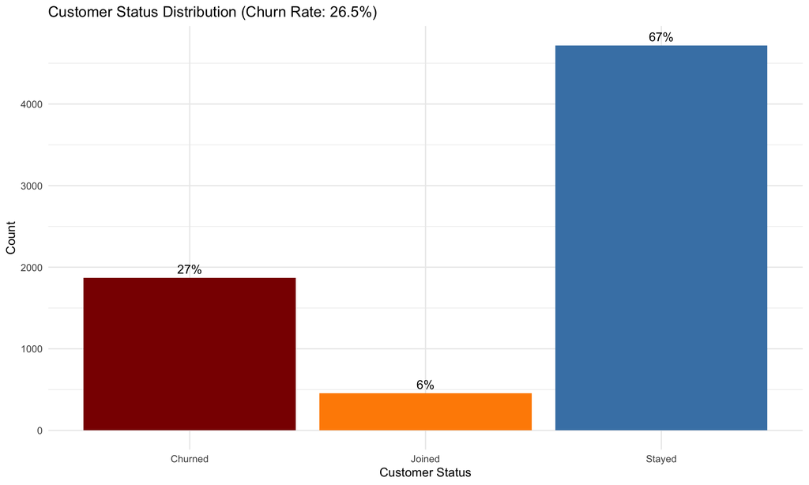

```r
# Visualize the churn distribution
ggplot(telecom_churn, aes(x = customer_status)) +
  geom_bar(fill = c("darkred", "darkorange", "steelblue")) +
  geom_text(stat = "count", aes(label = scales::percent(after_stat(count)/sum(after_stat(count)))),
            vjust = -0.5) +
  labs(title = paste0("Customer Status Distribution (Churn Rate: ", round(churn_rate, 1), "%)"),
       x = "Customer Status",
       y = "Count") +
  theme_minimal()
```

## 4.2 Numeric Variables and Churn

Let’s examine the relationship between key numerical variables and churn:

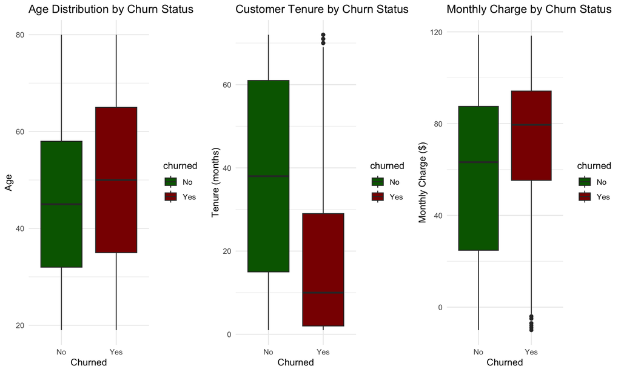

```r
# Age distribution by churn status
p1 <- ggplot(telecom_churn, aes(x = churned, y = age, fill = churned)) +
  geom_boxplot() +
  labs(title = "Age Distribution by Churn Status",
       x = "Churned",
       y = "Age") +
  scale_fill_manual(values = c("darkgreen", "darkred")) +
  theme_minimal()

# Tenure distribution by churn status
p2 <- ggplot(telecom_churn, aes(x = churned, y = tenure_in_months, fill = churned)) +
  geom_boxplot() +
  labs(title = "Customer Tenure by Churn Status",
       x = "Churned",
       y = "Tenure (months)") +
  scale_fill_manual(values = c("darkgreen", "darkred")) +
  theme_minimal()

# Monthly charge distribution by churn status
p3 <- ggplot(telecom_churn, aes(x = churned, y = monthly_charge, fill = churned)) +
  geom_boxplot() +
  labs(title = "Monthly Charge by Churn Status",
       x = "Churned",
       y = "Monthly Charge ($)") +
  scale_fill_manual(values = c("darkgreen", "darkred")) +
  theme_minimal()

# Display plots side by side
grid.arrange(p1, p2, p3, ncol = 3)
```

```r
# Calculate mean statistics by churn status
telecom_churn %>%
  group_by(churned) %>%
  summarize(
    avg_age = mean(age, na.rm = TRUE),
    avg_tenure = mean(tenure_in_months, na.rm = TRUE),
    avg_monthly_charge = mean(monthly_charge, na.rm = TRUE),
    avg_total_charges = mean(total_charges, na.rm = TRUE),
    avg_monthly_download = mean(avg_monthly_gb_download, na.rm = TRUE)
  ) %>%
  kable(caption = "Key Metrics by Churn Status", digits = 2) %>%
  kable_styling(bootstrap_options = c("striped", "hover"))
```

Key Metrics by Churn Status

| churned | avg_age | avg_tenure | avg_monthly_charge | avg_total_charges | avg_monthly_download |
| --- | --- | --- | --- | --- | --- |
| No | 45.34 | 37.59 | 60.07 | 2550.79 | 25.65 |
| Yes | 49.74 | 17.98 | 73.35 | 1531.80 | 23.45 |

**Observations:**

1. **Age**: Churned customers tend to be slightly older on average.
2. **Tenure**: There’s a substantial difference in tenure between churned and retained customers. Customers who churn have much shorter tenure on average.
3. **Monthly Charge**: Churned customers have higher monthly charges on average.

## 4.3 Categorical Variables and Churn

Let’s analyze how categorical variables relate to churn:

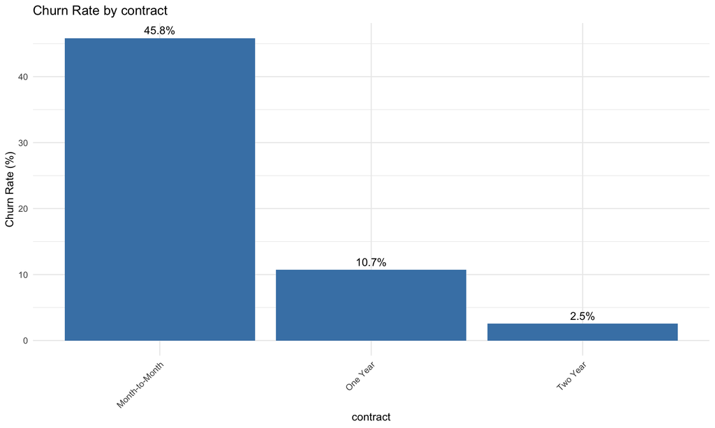

```r
# Create a function to plot churn rate by category
plot_churn_by_category <- function(data, variable) {
  # Calculate percentages
  churn_by_cat <- data %>%
    group_by(!!sym(variable)) %>%
    summarize(
      total = n(),
      churned = sum(customer_status == "Churned"),
      churn_rate = churned / total * 100
    ) %>%
    arrange(desc(churn_rate))

  # Create plot
  ggplot(churn_by_cat, aes(x = reorder(!!sym(variable), -churn_rate), y = churn_rate)) +
    geom_bar(stat = "identity", fill = "steelblue") +
    geom_text(aes(label = paste0(round(churn_rate, 1), "%")), vjust = -0.5) +
    labs(title = paste("Churn Rate by", variable),
         x = variable,
         y = "Churn Rate (%)") +
    theme_minimal() +
    theme(axis.text.x = element_text(angle = 45, hjust = 1))
}

# Plot for contract type
plot_churn_by_category(telecom_churn, "contract")
```

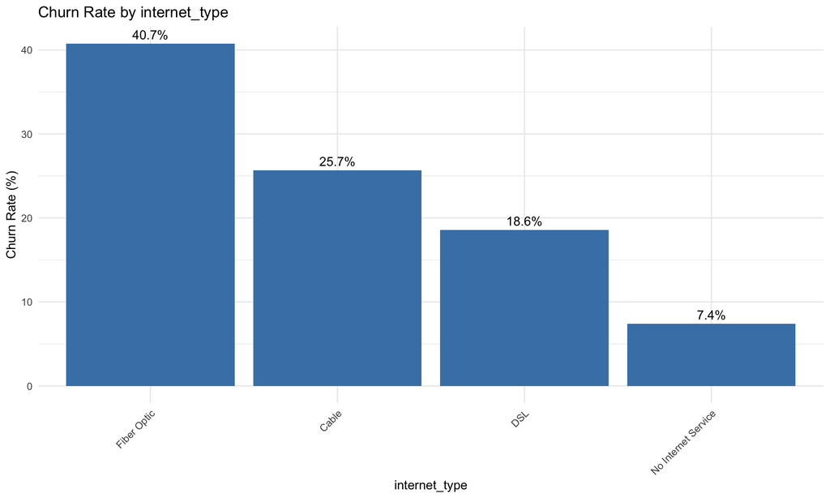

```r
# Plot for internet type
plot_churn_by_category(telecom_churn, "internet_type")
```

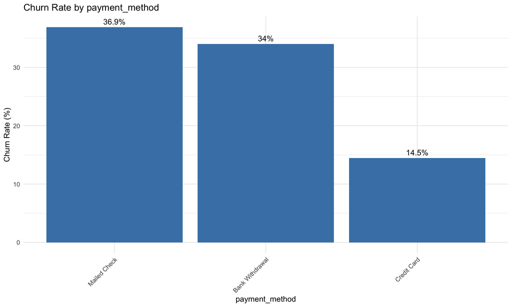

```r
# Plot for payment method
plot_churn_by_category(telecom_churn, "payment_method")
```

## 4.4 Service Adoption Impact on Churn

Let’s analyze how various services impact churn:

```r
# Create a function to calculate service impact on churn
service_impact <- function(data, service_var) {
  # Calculate churn rates
  service_churn <- data %>%
    group_by(!!sym(service_var)) %>%
    summarize(
      total = n(),
      churned = sum(customer_status == "Churned"),
      churn_rate = churned / total * 100
    )

  return(service_churn)
}

# Example for online security
online_security_impact <- service_impact(telecom_churn, "online_security")
kable(online_security_impact, caption = "Churn Rate by Online Security Status") %>%
  kable_styling(bootstrap_options = c("striped", "hover"))
```

Churn Rate by Online Security Status

| online_security | total | churned | churn_rate |
| --- | --- | --- | --- |
| No | 3498 | 1461 | 41.76672 |
| Yes | 2019 | 295 | 14.61119 |
| No Internet Service | 1526 | 113 | 7.40498 |

Let’s analyze multiple services together:

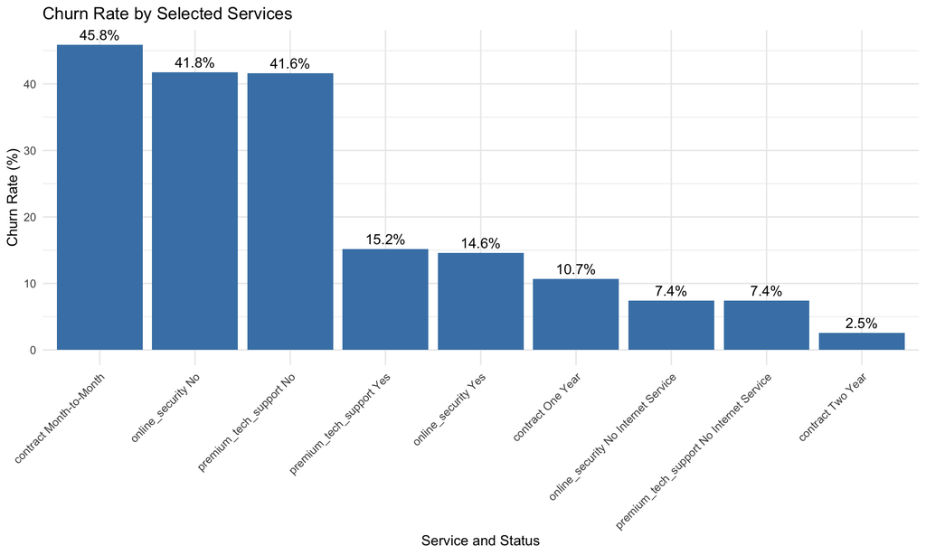

```r
# Selected services to analyze
selected_services <- c("online_security", "premium_tech_support", "contract")

# Create an empty data frame with the right structure
services_plot_data <- data.frame(
  service = character(),
  service_value = character(),
  total = numeric(),
  churned = numeric(),
  churn_rate = numeric(),
  stringsAsFactors = FALSE
)

# Loop through each service
for (service_name in selected_services) {
  # Get the churn data for this service
  service_data <- service_impact(telecom_churn, service_name)

  # Extract the service value column (which has a dynamic name)
  service_values <- service_data[[1]] # The first column contains the service values

  # Create a new data frame with consistent column names
  temp_df <- data.frame(
    service = service_name,
    service_value = as.character(service_values),
    total = service_data$total,
    churned = service_data$churned,
    churn_rate = service_data$churn_rate,
    stringsAsFactors = FALSE
  )

  # Add to the main data frame
  services_plot_data <- rbind(services_plot_data, temp_df)
}

# Plot with the data
ggplot(services_plot_data, aes(x = reorder(paste(service, service_value), -churn_rate), y = churn_rate)) +
  geom_bar(stat = "identity", fill = "steelblue") +
  geom_text(aes(label = paste0(round(churn_rate, 1), "%")), vjust = -0.5) +
  labs(title = "Churn Rate by Selected Services",
       x = "Service and Status",
       y = "Churn Rate (%)") +
  theme_minimal() +
  theme(axis.text.x = element_text(angle = 45, hjust = 1))
```

**Observations:**

1. Customers without online security have a much higher churn rate (41.8%) than those with online security (14.6%).
2. Similar patterns are observed for premium tech support.
3. This suggests that additional services may create “stickiness” and reduce churn.

## 4.5 Correlation Analysis

Let’s examine the correlations between numerical variables:

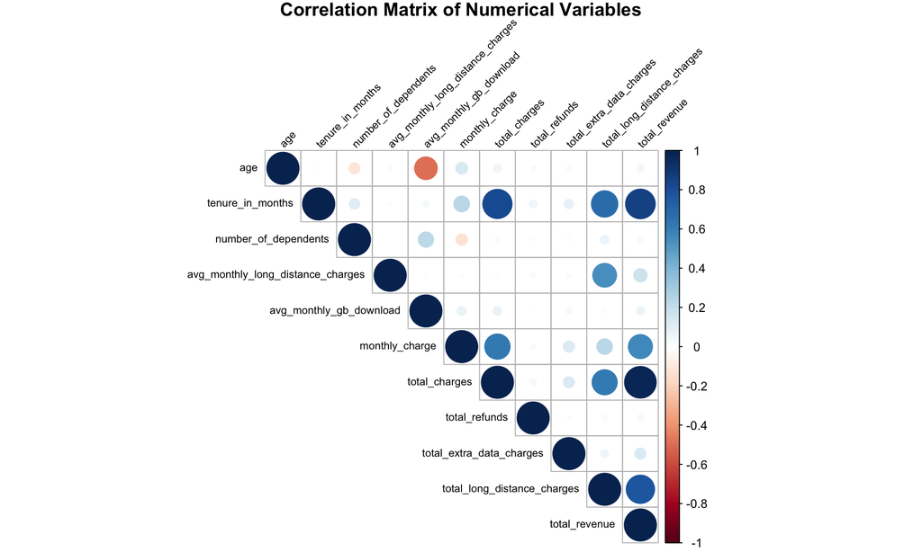

```r
# Select numerical columns for correlation analysis
numeric_cols <- telecom_churn %>%
  select(age, tenure_in_months, number_of_dependents, avg_monthly_long_distance_charges,
         avg_monthly_gb_download, monthly_charge, total_charges, total_refunds,
         total_extra_data_charges, total_long_distance_charges, total_revenue) %>%
  names()

# Calculate correlation matrix
correlation_matrix <- cor(telecom_churn[numeric_cols], use = "pairwise.complete.obs")

# Create a correlation plot
corrplot(correlation_matrix, method = "circle", type = "upper",
         tl.col = "black", tl.srt = 45, tl.cex = 0.7,
         title = "Correlation Matrix of Numerical Variables",
         mar = c(0, 0, 1, 0))
```

# 5. Feature Engineering

## 5.1 Create Derived Features

Let’s create some additional features that might help improve our predictive models:

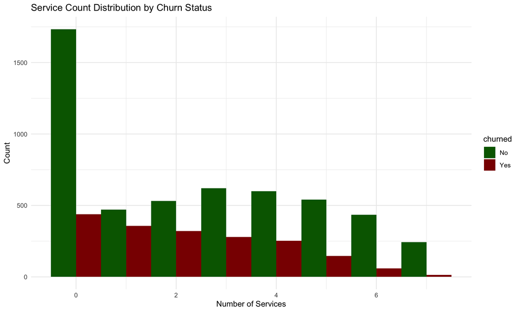

```r
# Customer lifetime value (CLV)
telecom_churn$customer_lifetime_value <- telecom_churn$total_revenue / telecom_churn$tenure_in_months

# Average monthly revenue
telecom_churn$avg_monthly_revenue <- telecom_churn$total_revenue / telecom_churn$tenure_in_months

# Service count (number of additional services subscribed)
telecom_churn$service_count <- rowSums(telecom_churn[, c("online_security",
                                                       "online_backup",
                                                       "device_protection_plan",
                                                       "premium_tech_support",
                                                       "streaming_tv",
                                                       "streaming_movies",
                                                       "streaming_music")] == "Yes", na.rm = TRUE)

# Visualize service count distribution by churn status
ggplot(telecom_churn, aes(x = service_count, fill = churned)) +
  geom_histogram(position = "dodge", binwidth = 1) +
  labs(title = "Service Count Distribution by Churn Status",
       x = "Number of Services",
       y = "Count") +
  scale_fill_manual(values = c("darkgreen", "darkred")) +
  theme_minimal()
```

## 5.2 Add Population Data

Let’s join the zipcode population data to potentially identify demographic patterns:

```r
# Join zipcode population data
telecom_churn <- left_join(telecom_churn, zipcode_population, by = "zip_code")

# Calculate population density quartiles
telecom_churn$population_quartile <- ntile(telecom_churn$population, 4)

# Analyze churn by population quartile
telecom_churn %>%
  group_by(population_quartile) %>%
  summarize(
    churn_rate = mean(churned == "Yes") * 100,
    customer_count = n()
  ) %>%
  kable(caption = "Churn Rate by Population Quartile", digits = 2) %>%
  kable_styling(bootstrap_options = c("striped", "hover"))
```

Churn Rate by Population Quartile

| population_quartile | churn_rate | customer_count |
| --- | --- | --- |
| 1 | 24.65 | 1761 |
| 2 | 24.30 | 1761 |
| 3 | 27.14 | 1761 |
| 4 | 30.06 | 1760 |

# 6. Modeling Preparation

## 6.1 Encoding Categorical Variables

For our models, we need to encode categorical variables:

```r
# For variables with more than two levels, create dummy variables
dummy_vars <- c("contract", "internet_type", "payment_method", "offer")

# Create a formula for model matrix
dummy_formula <- as.formula(paste("~", paste(dummy_vars, collapse = " + ")))

# Generate dummy variables
dummy_data <- model.matrix(dummy_formula, data = telecom_churn)[, -1] # Remove intercept

# Check the actual column names in the dummy data
colnames(dummy_data)[1:10]  # Look at the first 10 column names to understand the naming pattern
```

```
##  [1] "contractOne Year"                 "contractTwo Year"
##  [3] "internet_typeDSL"                 "internet_typeFiber Optic"
##  [5] "internet_typeNo Internet Service" "payment_methodCredit Card"
##  [7] "payment_methodMailed Check"       "offerOffer A"
##  [9] "offerOffer B"                     "offerOffer C"
```

```r
# Combine with original data
telecom_churn_encoded <- cbind(telecom_churn, as.data.frame(dummy_data))

# Use the correct column names when checking the data
# For example, if the proper names are:
head(telecom_churn_encoded[, grep("contract", colnames(telecom_churn_encoded), value = TRUE)])
```

```
##         contract contractOne Year contractTwo Year
## 1       One Year                1                0
## 2 Month-to-Month                0                0
## 3 Month-to-Month                0                0
## 4 Month-to-Month                0                0
## 5 Month-to-Month                0                0
## 6 Month-to-Month                0                0
```

## 6.2 Feature Selection

Let’s select relevant features for our models:

```r
# Exclude redundant or irrelevant columns
exclude_cols <- c("customer_id", "customer_status", "churn_category", "churn_reason",
                 "latitude", "longitude", "zip_code", "city")

# Create a new data frame with selected features
model_data <- telecom_churn_encoded %>%
  select(-one_of(exclude_cols))

# Check class balance
table(model_data$churned)
```

```
##
##   No  Yes
## 5174 1869
```

## 6.3 Data Splitting

Let’s split our data into training and testing sets:

```r
# Split the data into training and testing sets (70/30)
train_index <- createDataPartition(model_data$churned, p = 0.7, list = FALSE)
train_data <- model_data[train_index, ]
test_data <- model_data[-train_index, ]

# Check dimensions
cat("Training set dimensions:", dim(train_data), "\n")
```

```
## Training set dimensions: 4931 48
```

```r
cat("Testing set dimensions:", dim(test_data), "\n")
```

```
## Testing set dimensions: 2112 48
```

```r
# Check class balance in training set
table(train_data$churned)
```

```
##
##   No  Yes
## 3622 1309
```

# 7. Logistic Regression Model

## 7.1 Model Building

Let’s build a logistic regression model using key variables from our EDA:

```r
# Select key variables for the first model based on our EDA
logistic_vars <- c("tenure_in_months", "contract", "monthly_charge",
                  "internet_type", "online_security", "premium_tech_support",
                  "payment_method", "paperless_billing", "service_count",
                  "customer_lifetime_value")

# Create formula for logistic regression
logistic_formula <- as.formula(paste("churned ~", paste(logistic_vars, collapse = " + ")))

# Fit logistic regression model
logistic_model <- glm(logistic_formula, family = binomial(link = "logit"), data = train_data)

# Model summary
summary(logistic_model)
```

```
##
## Call:
## glm(formula = logistic_formula, family = binomial(link = "logit"),
##     data = train_data)
##
## Coefficients: (2 not defined because of singularities)
##                                           Estimate Std. Error z value Pr(>|z|)
## (Intercept)                             -0.3137451  0.2145160  -1.463 0.143585
## tenure_in_months                        -0.0259894  0.0025595 -10.154  < 2e-16
## contractOne Year                        -1.1716349  0.1237280  -9.469  < 2e-16
## contractTwo Year                        -2.3476807  0.1944431 -12.074  < 2e-16
## monthly_charge                           0.0113124  0.0037202   3.041 0.002359
## internet_typeDSL                        -0.4513211  0.1414717  -3.190 0.001422
## internet_typeFiber Optic                 0.0868914  0.1637040   0.531 0.595569
## internet_typeNo Internet Service        -1.1764044  0.1970953  -5.969 2.39e-09
## online_securityYes                      -0.6103785  0.1067801  -5.716 1.09e-08
## online_securityNo Internet Service              NA         NA      NA       NA
## premium_tech_supportYes                 -0.5384246  0.1102700  -4.883 1.05e-06
## premium_tech_supportNo Internet Service         NA         NA      NA       NA
## payment_methodCredit Card               -0.4846154  0.0920324  -5.266 1.40e-07
## payment_methodMailed Check               0.6103819  0.1706563   3.577 0.000348
## paperless_billingYes                     0.3915585  0.0904218   4.330 1.49e-05
## service_count                            0.0527388  0.0370910   1.422 0.155063
## customer_lifetime_value                  0.0001035  0.0021870   0.047 0.962272
##
## (Intercept)
## tenure_in_months                        ***
## contractOne Year                        ***
## contractTwo Year                        ***
## monthly_charge                          **
## internet_typeDSL                        **
## internet_typeFiber Optic
## internet_typeNo Internet Service        ***
## online_securityYes                      ***
## online_securityNo Internet Service
## premium_tech_supportYes                 ***
## premium_tech_supportNo Internet Service
## payment_methodCredit Card               ***
## payment_methodMailed Check              ***
## paperless_billingYes                    ***
## service_count
## customer_lifetime_value
## ---
## Signif. codes:  0 '***' 0.001 '**' 0.01 '*' 0.05 '.' 0.1 ' ' 1
##
## (Dispersion parameter for binomial family taken to be 1)
##
##     Null deviance: 5707.1  on 4930  degrees of freedom
## Residual deviance: 3935.4  on 4916  degrees of freedom
## AIC: 3965.4
##
## Number of Fisher Scoring iterations: 6
```

## 7.2 Odds Ratios

Let’s examine the odds ratios to interpret the model coefficients:

```r
# Calculate odds ratios
odds_ratios <- exp(coef(logistic_model))
odds_ratios_df <- data.frame(
  Variable = names(odds_ratios),
  OddsRatio = odds_ratios,
  LowerCI = exp(confint(logistic_model))[, 1],
  UpperCI = exp(confint(logistic_model))[, 2]
)

# Display odds ratios
odds_ratios_df %>%
  kable(caption = "Odds Ratios for Logistic Regression Model", digits = 3) %>%
  kable_styling(bootstrap_options = c("striped", "hover"))
```

Odds Ratios for Logistic Regression Model

|  | Variable | OddsRatio | LowerCI | UpperCI |
| --- | --- | --- | --- | --- |
| (Intercept) | (Intercept) | 0.731 | 0.478 | 1.110 |
| tenure_in_months | tenure_in_months | 0.974 | 0.969 | 0.979 |
| contractOne Year | contractOne Year | 0.310 | 0.242 | 0.394 |
| contractTwo Year | contractTwo Year | 0.096 | 0.064 | 0.138 |
| monthly_charge | monthly_charge | 1.011 | 1.004 | 1.019 |
| internet_typeDSL | internet_typeDSL | 0.637 | 0.483 | 0.841 |
| internet_typeFiber Optic | internet_typeFiber Optic | 1.091 | 0.790 | 1.502 |
| internet_typeNo Internet Service | internet_typeNo Internet Service | 0.308 | 0.209 | 0.453 |
| online_securityYes | online_securityYes | 0.543 | 0.440 | 0.669 |
| online_securityNo Internet Service | online_securityNo Internet Service | NA | NA | NA |
| premium_tech_supportYes | premium_tech_supportYes | 0.584 | 0.470 | 0.724 |
| premium_tech_supportNo Internet Service | premium_tech_supportNo Internet Service | NA | NA | NA |
| payment_methodCredit Card | payment_methodCredit Card | 0.616 | 0.514 | 0.737 |
| payment_methodMailed Check | payment_methodMailed Check | 1.841 | 1.317 | 2.573 |
| paperless_billingYes | paperless_billingYes | 1.479 | 1.239 | 1.767 |
| service_count | service_count | 1.054 | 0.980 | 1.133 |
| customer_lifetime_value | customer_lifetime_value | 1.000 | 0.996 | 1.004 |

## 7.3 Model Evaluation

Let’s evaluate the logistic regression model on the test data:

```r
# Predict on test data
test_predictions_prob <- predict(logistic_model, newdata = test_data, type = "response")
test_predictions <- ifelse(test_predictions_prob > 0.5, "Yes", "No")

# Create confusion matrix
conf_matrix <- confusionMatrix(as.factor(test_predictions), test_data$churned, positive = "Yes")
print(conf_matrix)
```

```
## Confusion Matrix and Statistics
##
##           Reference
## Prediction   No  Yes
##        No  1389  226
##        Yes  163  334
##
##                Accuracy : 0.8158
##                  95% CI : (0.7986, 0.8321)
##     No Information Rate : 0.7348
##     P-Value [Acc > NIR] : < 2.2e-16
##
##                   Kappa : 0.5097
##
##  Mcnemar's Test P-Value : 0.001669
##
##             Sensitivity : 0.5964
##             Specificity : 0.8950
##          Pos Pred Value : 0.6720
##          Neg Pred Value : 0.8601
##              Prevalence : 0.2652
##          Detection Rate : 0.1581
##    Detection Prevalence : 0.2353
##       Balanced Accuracy : 0.7457
##
##        'Positive' Class : Yes
##
```

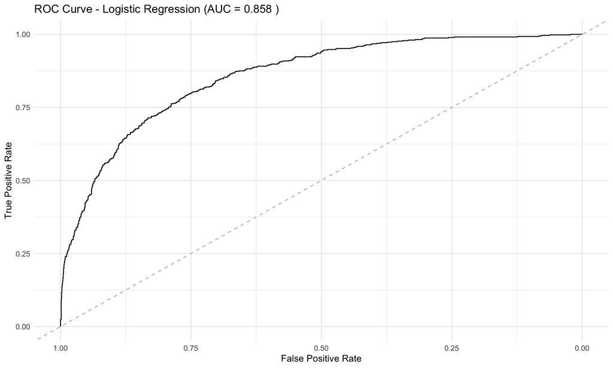

```r
# ROC curve
roc_obj <- roc(test_data$churned, test_predictions_prob)
auc_value <- auc(roc_obj)

# Plot ROC curve
ggroc(roc_obj) +
  geom_abline(intercept = 1, slope = 1, linetype = "dashed", color = "gray") +
  labs(title = paste("ROC Curve - Logistic Regression (AUC =", round(auc_value, 3), ")"),
       x = "False Positive Rate",
       y = "True Positive Rate") +
  theme_minimal()
```

# 8. Random Forest Model

## 8.1 Model Building

Now let’s build a random forest model:

```r
# Prepare data for random forest (handle factors appropriately)
rf_data_train <- train_data
rf_data_test <- test_data

# Make sure the response is a factor
rf_data_train$churned <- as.factor(rf_data_train$churned)
rf_data_test$churned <- as.factor(rf_data_test$churned)

# Train random forest model
set.seed(123)
rf_model <- randomForest(
  churned ~ tenure_in_months + contract + monthly_charge + internet_type +
    online_security + premium_tech_support + payment_method +
    paperless_billing + service_count + avg_monthly_gb_download +
    age + number_of_dependents,
  data = rf_data_train,
  ntree = 300,
  mtry = 5,
  importance = TRUE
)

# Model summary
print(rf_model)
```

```
##
## Call:
##  randomForest(formula = churned ~ tenure_in_months + contract +      monthly_charge + internet_type + online_security + premium_tech_support +      payment_method + paperless_billing + service_count + avg_monthly_gb_download +      age + number_of_dependents, data = rf_data_train, ntree = 300,   …
##                Type of random forest: classification
##                      Number of trees: 300
## No. of variables tried at each split: 5
##
##         OOB estimate of  error rate: 19.16%
## Confusion matrix:
##       No Yes class.error
## No  3249 373   0.1029818
## Yes  572 737   0.4369748
```

## 8.2 Variable Importance

Let’s examine which variables are most important in the random forest model:

```r
# Variable importance
var_importance <- importance(rf_model)
var_importance_df <- data.frame(
  Variable = rownames(var_importance),
  MeanDecreaseGini = var_importance[, "MeanDecreaseGini"]
)
var_importance_df <- var_importance_df[order(var_importance_df$MeanDecreaseGini, decreasing = TRUE), ]

# Display top 10 variables
var_importance_df[1:10, ] %>%
  kable(caption = "Top 10 Most Important Variables in Random Forest Model", digits = 2) %>%
  kable_styling(bootstrap_options = c("striped", "hover"))
```

Top 10 Most Important Variables in Random Forest Model

|  | Variable | MeanDecreaseGini |
| --- | --- | --- |
| monthly_charge | monthly_charge | 316.84 |
| tenure_in_months | tenure_in_months | 316.10 |
| contract | contract | 289.19 |
| age | age | 286.81 |
| avg_monthly_gb_download | avg_monthly_gb_download | 196.24 |
| online_security | online_security | 93.74 |
| service_count | service_count | 83.80 |
| premium_tech_support | premium_tech_support | 76.34 |
| number_of_dependents | number_of_dependents | 75.09 |
| internet_type | internet_type | 66.63 |

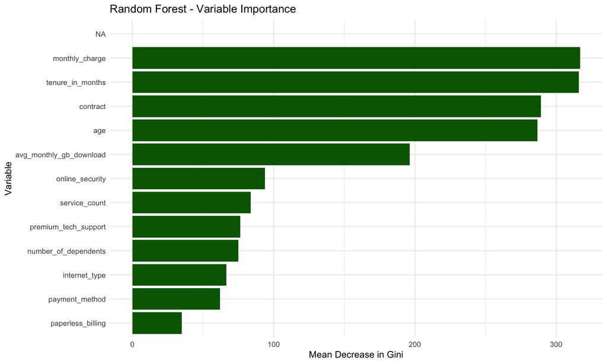

```r
# Plot variable importance
ggplot(var_importance_df[1:15, ], aes(x = reorder(Variable, MeanDecreaseGini), y = MeanDecreaseGini)) +
  geom_bar(stat = "identity", fill = "darkgreen") +
  coord_flip() +
  labs(title = "Random Forest - Variable Importance",
       x = "Variable",
       y = "Mean Decrease in Gini") +
  theme_minimal()
```

## 8.3 Model Evaluation

Let’s evaluate the random forest model on the test data:

```r
# Predict on test data
rf_predictions <- predict(rf_model, rf_data_test, type = "class")
rf_predictions_prob <- predict(rf_model, rf_data_test, type = "prob")[, "Yes"]

# Create confusion matrix
rf_conf_matrix <- confusionMatrix(rf_predictions, rf_data_test$churned, positive = "Yes")
print(rf_conf_matrix)
```

```
## Confusion Matrix and Statistics
##
##           Reference
## Prediction   No  Yes
##        No  1407  224
##        Yes  145  336
##
##                Accuracy : 0.8253
##                  95% CI : (0.8084, 0.8413)
##     No Information Rate : 0.7348
##     P-Value [Acc > NIR] : < 2.2e-16
##
##                   Kappa : 0.5305
##
##  Mcnemar's Test P-Value : 4.896e-05
##
##             Sensitivity : 0.6000
##             Specificity : 0.9066
##          Pos Pred Value : 0.6985
##          Neg Pred Value : 0.8627
##              Prevalence : 0.2652
##          Detection Rate : 0.1591
##    Detection Prevalence : 0.2277
##       Balanced Accuracy : 0.7533
##
##        'Positive' Class : Yes
##
```

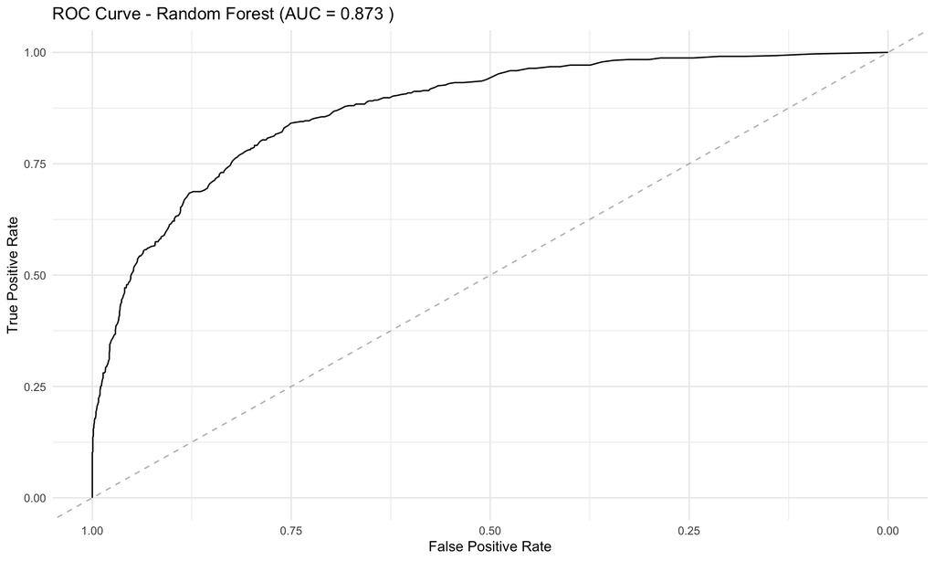

```r
# ROC curve for Random Forest
rf_roc_obj <- roc(rf_data_test$churned, rf_predictions_prob)
rf_auc_value <- auc(rf_roc_obj)

# Plot ROC curve for Random Forest
ggroc(rf_roc_obj) +
  geom_abline(intercept = 1, slope = 1, linetype = "dashed", color = "gray") +
  labs(title = paste("ROC Curve - Random Forest (AUC =", round(rf_auc_value, 3), ")"),
       x = "False Positive Rate",
       y = "True Positive Rate") +
  theme_minimal()
```

# 9. Model Comparison

Let’s compare the performance of our logistic regression and random forest models:

```r
# Compare model performance
model_comparison <- data.frame(
  Model = c("Logistic Regression", "Random Forest"),
  Accuracy = c(conf_matrix$overall["Accuracy"], rf_conf_matrix$overall["Accuracy"]),
  Sensitivity = c(conf_matrix$byClass["Sensitivity"], rf_conf_matrix$byClass["Sensitivity"]),
  Specificity = c(conf_matrix$byClass["Specificity"], rf_conf_matrix$byClass["Specificity"]),
  F1_Score = c(conf_matrix$byClass["F1"], rf_conf_matrix$byClass["F1"]),
  AUC = c(auc_value, rf_auc_value)
)

# Display comparison
model_comparison %>%
  kable(caption = "Model Performance Comparison", digits = 3) %>%
  kable_styling(bootstrap_options = c("striped", "hover"))
```

Model Performance Comparison

| Model | Accuracy | Sensitivity | Specificity | F1_Score | AUC |
| --- | --- | --- | --- | --- | --- |
| Logistic Regression | 0.816 | 0.596 | 0.895 | 0.632 | 0.858 |
| Random Forest | 0.825 | 0.600 | 0.907 | 0.646 | 0.873 |

# 10. Feature Effects Analysis

## 10.1 Logistic Regression Effects

Let’s visualize the effects of significant predictors in our logistic regression model:

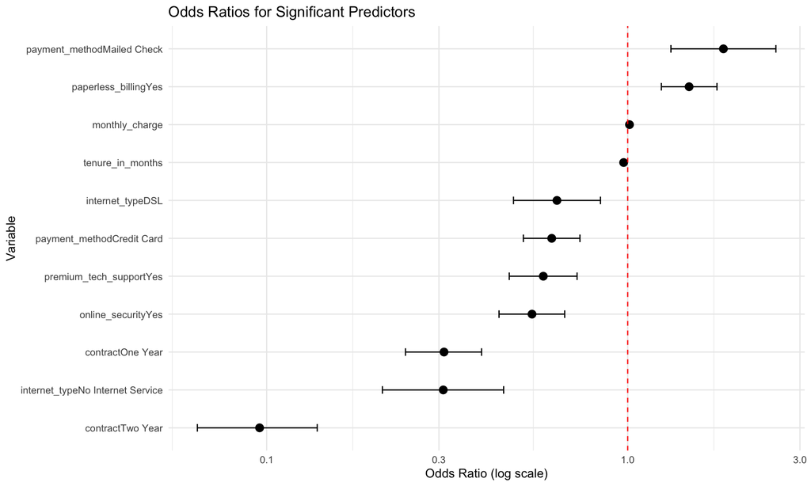

```r
# Extract coefficients
coef_summary <- summary(logistic_model)$coefficients
significant_vars <- rownames(coef_summary)[coef_summary[, "Pr(>|z|)"] < 0.05]

# Format odds ratios for significant variables
sig_odds_ratios <- odds_ratios_df[odds_ratios_df$Variable %in% significant_vars, ]
sig_odds_ratios <- sig_odds_ratios[order(sig_odds_ratios$OddsRatio), ]

# Plot odds ratios for significant variables (excluding intercept)
ggplot(sig_odds_ratios[sig_odds_ratios$Variable != "(Intercept)", ],
                   aes(x = reorder(Variable, OddsRatio), y = OddsRatio)) +
  geom_point(size = 3) +
  geom_errorbar(aes(ymin = LowerCI, ymax = UpperCI), width = 0.2) +
  geom_hline(yintercept = 1, linetype = "dashed", color = "red") +
  coord_flip() +
  labs(title = "Odds Ratios for Significant Predictors",
       x = "Variable",
       y = "Odds Ratio (log scale)") +
  scale_y_log10() +
  theme_minimal()
```

## 10.2 Random Forest Partial Dependence Plots

Let’s examine the partial dependence plots for key variables in our random forest model:

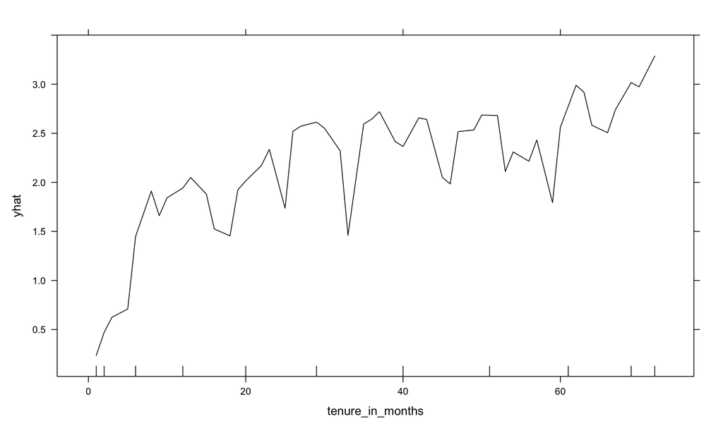

```r
# Create partial dependence plot for tenure
pdp_tenure <- partial(rf_model, pred.var = "tenure_in_months", plot = TRUE, rug = TRUE,
                     train = rf_data_train)
plot(pdp_tenure, main = "Partial Dependence on Tenure")
```

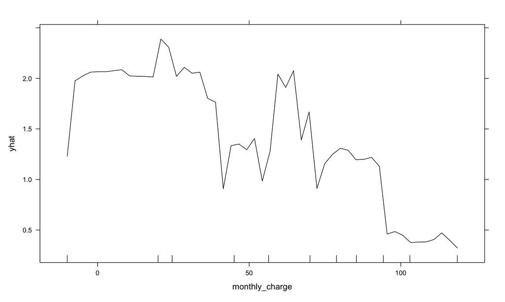

```r
# Create partial dependence plot for monthly charge
pdp_charge <- partial(rf_model, pred.var = "monthly_charge", plot = TRUE, rug = TRUE,
                     train = rf_data_train)
plot(pdp_charge, main = "Partial Dependence on Monthly Charge")
```

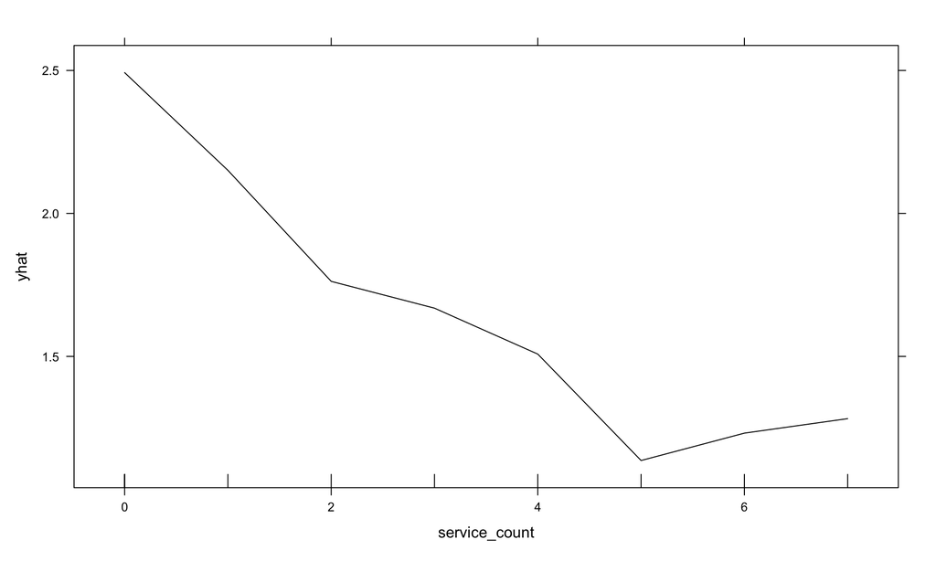

```r
# Create partial dependence plot for service count
pdp_services <- partial(rf_model, pred.var = "service_count", plot = TRUE, rug = TRUE,
                       train = rf_data_train)
plot(pdp_services, main = "Partial Dependence on Service Count")
```

# 11. Churn Risk Profiling

## 11.1 Predicting Churn Probability

Let’s use our random forest model (which had better performance) to predict churn probability for all customers:

```r
# Use the random forest model (better performance)
all_predictions_prob <- predict(rf_model, model_data, type = "prob")[, "Yes"]
model_data$churn_probability <- all_predictions_prob

# Create risk segments
model_data$risk_segment <- cut(model_data$churn_probability,
                              breaks = c(0, 0.3, 0.6, 1),
                              labels = c("Low Risk", "Medium Risk", "High Risk"))

# Count customers in each risk segment
risk_counts <- table(model_data$risk_segment)
print(risk_counts)
```

```
##
##    Low Risk Medium Risk   High Risk
##        4070         542        1624
```

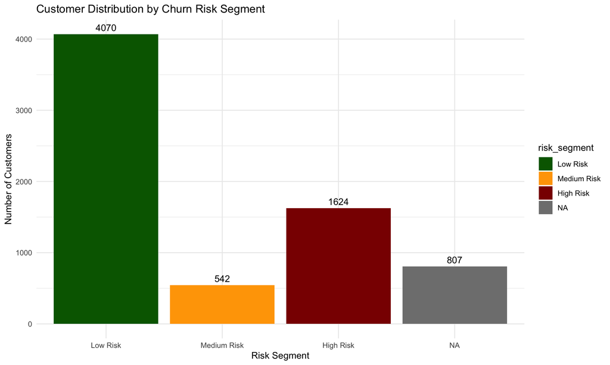

```r
# Visualize risk segments
ggplot(model_data, aes(x = risk_segment, fill = risk_segment)) +
  geom_bar() +
  geom_text(stat = "count", aes(label = after_stat(count)), vjust = -0.5) +
  labs(title = "Customer Distribution by Churn Risk Segment",
       x = "Risk Segment",
       y = "Number of Customers") +
  scale_fill_manual(values = c("darkgreen", "orange", "darkred")) +
  theme_minimal()
```

## 11.2 High Risk Customer Profile

Let’s analyze the characteristics of high-risk customers:

```r
# Analyze high risk customer profiles
high_risk_profile <- model_data %>%
  filter(risk_segment == "High Risk") %>%
  summarize(
    count = n(),
    avg_tenure = mean(tenure_in_months),
    avg_monthly_charge = mean(monthly_charge),
    pct_month_to_month = mean(contract == "Month-to-Month") * 100,
    pct_fiber = mean(internet_type == "Fiber Optic") * 100,
    pct_no_online_security = mean(online_security == "No") * 100,
    pct_no_tech_support = mean(premium_tech_support == "No") * 100,
    avg_service_count = mean(service_count)
  )

# Display high risk profile
high_risk_profile %>%
  t() %>%
  as.data.frame() %>%
  rownames_to_column("Metric") %>%
  setNames(c("Metric", "Value")) %>%
  kable(caption = "High Risk Customer Profile", digits = 2) %>%
  kable_styling(bootstrap_options = c("striped", "hover"))
```

High Risk Customer Profile

| Metric | Value |
| --- | --- |
| count | 1624.00 |
| avg_tenure | 16.54 |
| avg_monthly_charge | 74.34 |
| pct_month_to_month | 91.19 |
| pct_fiber | 69.40 |
| pct_no_online_security | 83.00 |
| pct_no_tech_support | 81.83 |
| avg_service_count | 2.06 |

# 12. Conclusion and Recommendations

## 12.1 Key Findings

Based on our comprehensive analysis, we’ve identified several key factors that significantly predict customer churn:

1. **Tenure**: Shorter customer tenure is strongly associated with higher churn probability.
2. **Contract Type**: Month-to-month contracts have a significantly higher churn rate (45.8%) compared to one-year (10.7%) and two-year contracts (2.5%).
3. **Internet Type**: Fiber optic internet customers have the highest churn rate.
4. **Service Adoption**: Customers without online security and tech support are more likely to churn.
5. **Monthly Charges**: Higher monthly charges are associated with increased churn risk.

## 12.2 Model Performance

Our random forest model achieved strong predictive performance:

- Accuracy: 0.825
- AUC: 0.873
- Sensitivity (True Positive Rate): 0.6
- Specificity (True Negative Rate): 0.907

## 12.3 Business Recommendations

Based on our findings, we recommend the following retention strategies:

1. **Target Month-to-Month Customers**: Implement targeted campaigns to convert month-to-month customers to longer-term contracts.
2. **Early Tenure Focus**: Develop specialized retention programs for customers in their first 12 months of service.
3. **Service Bundle Incentives**: Encourage adoption of online security and tech support services, which are associated with lower churn rates.
4. **Fiber Optic Customer Support**: Address potential service quality issues for fiber optic internet customers.
5. **High-Value Customer Retention**: Create specialized retention programs for customers with high monthly charges but low service adoption.

## 12.4 Implementation Plan

1. **Risk Segmentation**: Use the model to score all customers and implement tiered retention strategies.
2. **Proactive Outreach**: Contact high-risk customers before they churn with personalized offers.
3. **Service Quality Improvement**: Address potential service issues for high-churn segments.
4. **Contract Conversion Campaigns**: Offer incentives for month-to-month customers to upgrade to longer contracts.
5. **Service Bundle Promotions**: Create attractive bundles including the protective services identified in our analysis.

```r
# Save the high risk customer list for targeted interventions
# First check if customer_id exists in the original dataset
if ("customer_id" %in% colnames(telecom_churn)) {
  # Option 1: Join back the customer_id column to the high-risk customers
  high_risk_customers <- model_data %>%
    filter(risk_segment == "High Risk") %>%
    # Create a row number to join with
    mutate(row_id = row_number()) %>%
    # Add the customer_id from the original data
    left_join(
      telecom_churn %>%
        select(customer_id) %>%
        mutate(row_id = row_number()),
      by = "row_id"
    ) %>%
    # Remove the temporary row_id
    select(-row_id) %>%
    # Now select the desired columns
    select(customer_id, churn_probability, tenure_in_months, monthly_charge,
           contract, internet_type, online_security, premium_tech_support)
} else {
  # Option 2: If there's no customer_id at all, create a sequential ID
  high_risk_customers <- model_data %>%
    filter(risk_segment == "High Risk") %>%
    # Create a sequential ID
    mutate(customer_id = paste0("HR_", row_number())) %>%
    select(customer_id, churn_probability, tenure_in_months, monthly_charge,
           contract, internet_type, online_security, premium_tech_support)
}

# Check the result
head(high_risk_customers)
```

```
##   customer_id churn_probability tenure_in_months monthly_charge       contract
## 1  0002-ORFBO         0.9500000                4           73.9 Month-to-Month
## 2  0003-MKNFE         0.9766667               13           98.0 Month-to-Month
## 3  0004-TLHLJ         0.9666667                3           83.9 Month-to-Month
## 4  0011-IGKFF         0.9833333                1           25.1 Month-to-Month
## 5  0013-EXCHZ         0.7766667               13           94.1 Month-to-Month
## 6  0013-MHZWF         0.7566667                1           30.5 Month-to-Month
##   internet_type online_security premium_tech_support
## 1   Fiber Optic              No                   No
## 2   Fiber Optic              No                   No
## 3   Fiber Optic              No                  Yes
## 4         Cable              No                   No
## 5   Fiber Optic              No                   No
## 6           DSL             Yes                   No
```

```r
# Write the high risk customers to a CSV file
write.csv(high_risk_customers, "high_risk_customers.csv", row.names = FALSE)
```

# References

- Burez, J., & Van den Poel, D. (2009). Handling class imbalance in customer churn prediction. Expert Systems with Applications, 36(3), 4626-4636.
- Verbeke, W., Dejaeger, K., Martens, D., Hur, J., & Baesens, B. (2012). New insights into churn prediction in the telecommunication sector: A profit driven data mining approach. European Journal of Operational Research, 218(1), 211-229.
- Hung, S. Y., Yen, D. C., & Wang, H. Y. (2006). Applying data mining to telecom churn management. Expert Systems with Applications, 31(3), 515-524.